# Literatur & weitere Informationen zum Riesen-Bärenklau im Oberen Edertal

Maja Koch

2026-02-09

## Besonders empfohlene Literatur: **Webseite des Landkreises Waldeck-Frankenberg**:

### https://www.landkreis-waldeck-frankenberg.de/buergerservice/leistungen/HES:entry:65119-VLR/bekaempfung-der-herkulesstaude-riesenbaerenklau/

### Dort können ebenfalls Kontaktmöglichkeiten, Empfehlungen für Schutzkleidung, weitere Bilder und Informationen über die Herkulesstaude gefunden werden.

## **Literatur**

### 1. *Anibaba, Q.A., Dyderski, M.K. & A.M. Jagodzinski (2022)*: Predicted range shifts of invasive giant hogweed (Heracleum mantegazzianum) in Europe. SCIENCE OF THE TOTAL ENVIRONMENT 825/154053: 1-9.

### 2. *Andersen, U.V. & B. Calov (1996)*: Long-term effects of sheep grazing on giant hogweed (Heracleum mantegazzianum). Hydrobiologia 340: 277-284.

### 3. *Bogusch, P., Vojtová, T. & J. Hadrava (2023)*: High abundance but low diversity of floral visitors on invasive Heracleum mantegazzianum (Apiaceae). Neobiota 86: 193-207.

### 4. *Gruľová, D., Baranová, B., Eliašová, A., Brun, C., Fejér, J., Kron, I., Campone, L., Pagliari, S., Nastišin, Ľ., & V. Sedlák (2024)*: Does the Invasive Heracleum mantegazzianum Influence Other Species by Allelopathy? Plants, 13/10: 1-17

### 5. *Hyvönen, T.T., Hagner, M.M., Hurme, T.K., Lindqvist, B.E. & H.J. Ojanen (2023)*: Control of Heracleum mantegazzianum with pyrolysis liquid products. Weed Research 63/5: 311-316.

### 6. *Kowarik, I. (2010)*: Biologische Invasionen. Neophyten und Neozoen in Mitteleuropa. 2. Auflage. Stuttgart.

### 7. *Landesamt für Natur, Umwelt und Verbraucherschutz Nordrhein-Westfalen (LANUV) (2011)*: Der Riesenbärenklau im Garten…ganz schön (und) gefährlich. https://www.google.com/url?sa=t&source=web&rct=j&opi=89978449&url=https://www.langen.de/de/datei/download/id/44468,1018/riesenbaerenklau.pdf&ved=2ahUKEwiwr_3Yu8ySAxV0gv0HHci7EjAQFnoECBoQAQ&usg=AOvVaw0cDrUsRRib9JIH-2vTksM6 (letzter Abruf: 09.01.2026)

### 8. *Landkreis Waldeck-Frankenberg (o.J.)*: Bekämpfung der Herkulesstaude (Riesenbärenklau). https://www.landkreis-waldeck-frankenberg.de/buergerservice/leistungen/HES:entry:65119-VLR/bekaempfung-der-herkulesstaude-riesenbaerenklau/ (letzter Abruf: 11.02.2026)

### 9. *Pergl, J. (2011)*: Gebirgsriesen aus dem Garten - der Riesen-Bärenklau. In: Nentwig, W. (2011): Unheimliche Eroberer. Invasive Pflanzen und Tiere in Europa. Bern. S. 41-48.

### 10. *Gesetz zum Schutz der Kulturpflanzen (Pflanzenschutzgesetz - PflSchG) (2012)*: § 12 Vorschriften für die Anwendung von Pflanzenschutzmitteln. https://www.gesetze-im-internet.de/pflschg_2012/__12.html (letzter Abruf: 11.02.2026)

### 11. *Rajmis, S., Thiele, J. & R. Marggraf (2016)*: A cost-benefit analysis of controlling giant hogweed (Heracleum mantegazzianum) in Germany using a choice experiment approach. Neobiota 31: 19-41.

### 12. *Regierungspräsidium Gießen, Dezernat Pflanzenschutzdienst (o.J.)*: Gesetz zum Schutz der Kulturpflanzen (Pflanzenschutzgesetz - PflSchG). https://pflanzenschutzdienst.rp-giessen.de/pflanzenschutzinfos/rechtsgrundlagen/pflanzenschutzgesetz/ (letzter Abruf: 11.02.2026)

### 13. *Thiele, J. & A. Otte (2006)*: Analysis of habitats and communities invaded by Heracleum mantegazzianum Somm. Et Lev. (Giant Hogweed) in Germany. Phytocoenologia 36/2: 281-320.

### 14. *Thiele, J. & A. Otte (2007a)*: 9. Impact of Heracleum mantegazzianum on invaded vegetation and human activities. In: Pysek, P., Cock, M.J.W., Nentwig, W. & H.P. Ravn (Hrsg.): Ecology and Management of Giant Hogweed (Heracleum mantegazzianum). CAB International: 144-156.

### 15. *Thiele, J. & A. Otte (2007b)*: Invasion patterns of Heracleum mantegazzianum in Germany on the regional and landscape scales. Journal for Nature Conversation 16: 61-71.

## **Weitere interessante Grafiken**

### Vorkommen des Riesen-Bärenklaus nach Vorkommen in Habitaten zwischen 2002 und 2003, Quelle: Thiele & Otte 2007, S.67

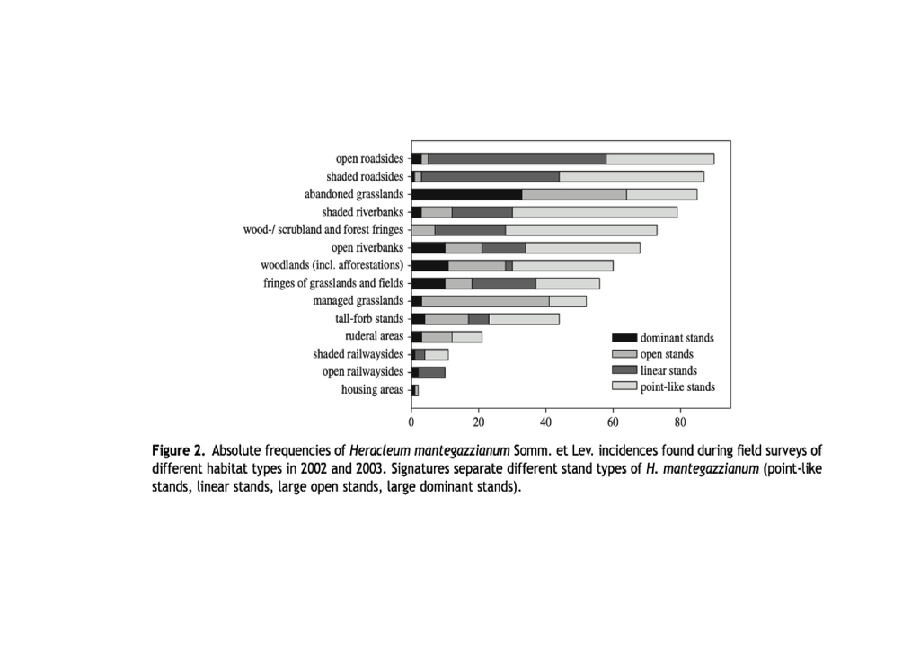

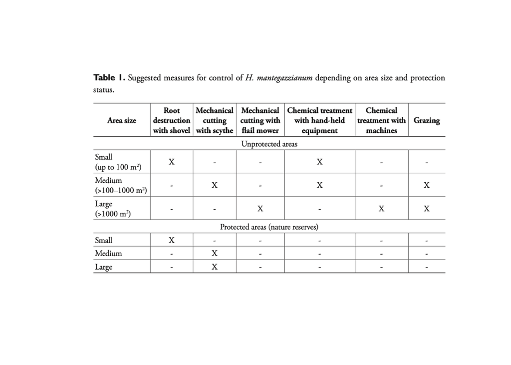

### Geschätzter Arbeitsaufwand nach Entfernungsmethode, Quelle: Rajmis, Thiele & Marggraf 2016, S. 24

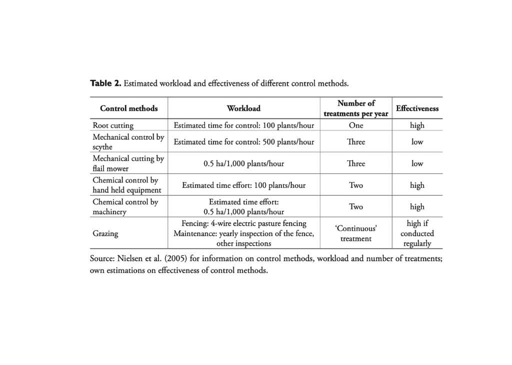

## **Weitere Bilder**

### Blätter des Riesen-Bärenklaus (O.Koch 2025)

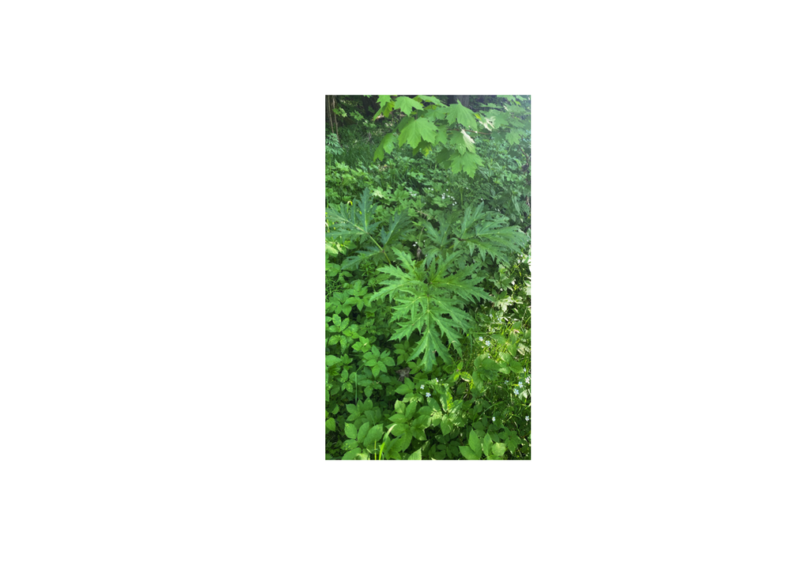

### Blätter und purpur gefleckter Stängel (O.Koch 2025)

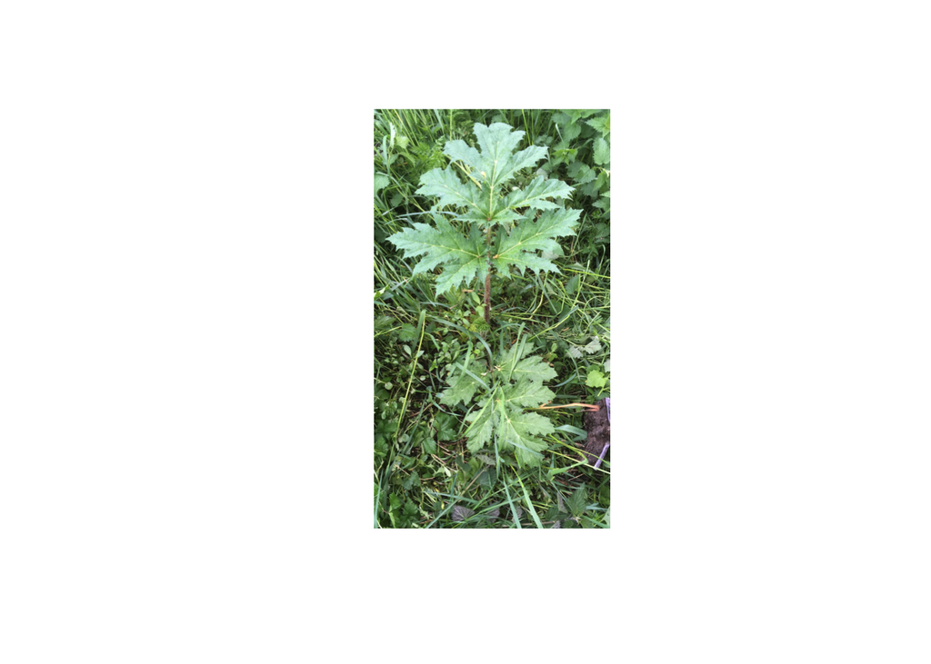